# Day 2: Introducing the Tidyverse

### Now let’s add a little spice.

This will help when deciding what to style to make your graph. We prefer *geom_boxplot()*, *geom_smooth()*, *geom_point()*, *geom_jitter*, and *geom_line()*. These will be familiar to most people who might find themselves looking at your graph and are therefore the most powerful tools for telling a story. That’s helpful because you want your audience to spend time looking at what the graph is saying and not by being confused because they’ve never seen a violin plot before.

This graph answers the question of how popularity changes as year changes, with year as a factor.

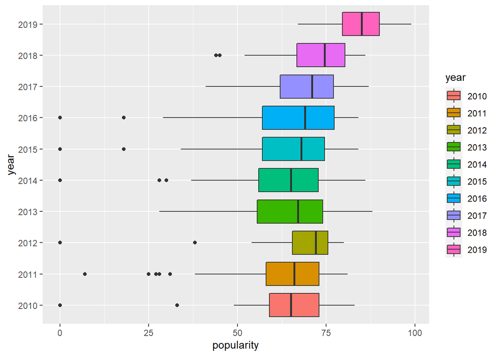

```r
spotify %>% # this is a pipe, we'll learn about it in a second
  mutate(year = as.factor(year)) %>% # this is taking year, which is currently a double, and changing it into a factor. this is a mutate, we'll learn about that in a second as well.
  ggplot(aes(x = popularity, y = year, group = year, fill = year)) + #we need to always have a grouping variable when we make boxplots, this is the setup
  geom_boxplot() # this is the boxplot layer
```

# But what happens if you have “ugly” data?

# dplyr

dplyr and tidyr are amazing packages, albeit tricky at first. Don’t worry, while making this presentation, StackOverflowed was visited at least six things!

In order to use dplyr, we need to think about data frames as objects; they can be changed (mutated), filtered, and summarized.

# %>%

The above symbol is what’s known as a pipe in dplyr. The pipe signifies that you are taking the data frame (our example data frame is *spotify*) and putting the whole data frame through a series of functions to get a whole new data frame. See the example below.

For example, we can use dplyr to create a new data frame which answers the question, “What artist has the most number of songs in the Billboard Hot 100 from 2010-2019?” We can see that the answer is Katy Perry, with 17 songs, and Justin Bieber at a close second with 16 songs.

Helpful tip: typing *%>%* out every time is tedious and requires some odd finger-stretching. Instead, try using the shortcut which is control + shift + M for windows and shift + command + M for apple.

```r
number_of_songs <- spotify %>% # take spotify dataframe
  group_by(artist) %>% # group by artist
  count() %>% # count each instance of artist
  arrange(desc(n)) %>% # arrange in descending order by n
  rename(number_of_songs = n)

head(number_of_songs)
```

```
## # A tibble: 6 x 2
## # Groups:   artist [6]
##   artist        number_of_songs
##   <chr>                   <int>
## 1 Katy Perry                 17
## 2 Justin Bieber              16
## 3 Maroon 5                   15
## 4 Rihanna                    15
## 5 Lady Gaga                  14
## 6 Bruno Mars                 13
```

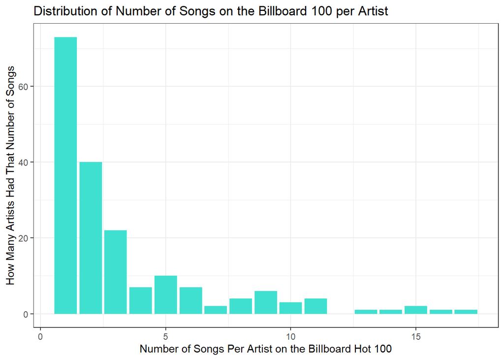

```r
ggplot(data = number_of_songs, mapping = aes(x=number_of_songs)) +
  geom_bar(fill="turquoise") +
  labs(x="Number of Songs Per Artist on the Billboard Hot 100", y="How Many Artists Had That Number of Songs", title="Distribution of Number of Songs on the Billboard 100 per Artist") +
  theme_bw()
```

```r
# We can see that this graph shows most artists only have one or two songs on the Billboard Hot 100, but a few like Katy Perry and Justin Bieber have so many.
```

### Transforming Data

Sometimes, we need to transform data. For example, the Spotify data has a column called duration, but it’s in seconds. What if we wanted to have a column for minutes and seconds (with seconds as a remainder?)

The mutate function does all that and a bag of chips! The mutate function is incredibly useful. Mutate makes a brand-new column of your data that has some transformation applied to it from an existing column. Therefore, each observation has the same mutate function applied to it! Let’s see how it works.

```r
spotify_durations <- spotify %>%
  select(title, duration) %>% # i only wanted a few of the data columns - title and duration
  mutate(minutes = duration %/% 60) %>% # %/% gives the dividend without remainder
  mutate(seconds = sprintf("%02d", duration %% 60)) %>% # gives the remainder with leading zero as needed
  mutate(total_time = paste0(minutes,":", seconds)) # paste minutes and seconds to get total time

head(spotify_durations)
```

```
## # A tibble: 6 x 5
##   title                duration minutes seconds total_time
##   <chr>                   <dbl>   <dbl> <chr>   <chr>
## 1 Hey, Soul Sister          217       3 37      3:37
## 2 Love The Way You Lie      263       4 23      4:23
## 3 TiK ToK                   200       3 20      3:20
## 4 Bad Romance               295       4 55      4:55
## 5 Just the Way You Are      221       3 41      3:41
## 6 Baby                      214       3 34      3:34
```

### Filtering & Selecting Data

Let’s take a look at our Spotify data. A lot of popular songs are by Bruno Mars. How many are there, and what are they? To figure this out, we’re going to use *filter()*, which looks for matching rows in the dataset.

```r
bruno_mars <- spotify %>%
  filter(artist == "Bruno Mars") #artist name must be equal to Bruno Mars. We use the double equals sign in CS

head(bruno_mars)
```

```
## # A tibble: 6 x 8
##   title                artist     genre  year   bpm    dB duration popularity
##   <chr>                <chr>      <chr> <dbl> <dbl> <dbl>    <dbl>      <dbl>
## 1 Just the Way You Are Bruno Mars pop    2010   109    -5      221         78
## 2 Marry You            Bruno Mars pop    2010   145    -5      230         73
## 3 Just the Way You Are Bruno Mars pop    2011   109    -5      221         78
## 4 Grenade              Bruno Mars pop    2011   110    -7      223         75
## 5 Marry You            Bruno Mars pop    2011   145    -5      230         73
## 6 Locked Out of Heaven Bruno Mars pop    2012   144    -4      233         79
```

We took our spotify data and piped it to the *filter()* function in dplyr. We wanted only the songs that were by Bruno Mars. We need to use the double equals sign (==), because if you only use one equals sign (=), R throws an error. You can try it!

You can also use different computer logic symbols with *filter()*.

```r
# Now, you try! Pipe the Spotify dataset to a make a tibble of only songs by Katy Perry called katy_perry

# bonus challenge! Pipe the Spotify data set to make a tibble of songs by Katy Perry OR Lady Gaga.
```

```r
title_artist <- spotify %>%
  select(title, artist)

head(title_artist)
```

```
## # A tibble: 6 x 2
##   title                artist
##   <chr>                <chr>
## 1 Hey, Soul Sister     Train
## 2 Love The Way You Lie Eminem
## 3 TiK ToK              Kesha
## 4 Bad Romance          Lady Gaga
## 5 Just the Way You Are Bruno Mars
## 6 Baby                 Justin Bieber
```

```r
# Now, you try! Select only the genre column to a dataset called genres.
```

### Summarizing Data

Sometimes, you don’t want thousands of rows of data. Sometimes you only want a summary. That’s when we use two best-friend functions in R, *group_by()* and *summarize()*.

The below data frame answers the question: What was the average popularity score of a song for each year?

```r
spotify_popularity <- spotify %>% # takes spotify
  group_by(year) %>% #groups by each year 2010-2019
  summarize(mean_popularity = mean(popularity)) # summarizes mean of popularity

head(spotify_popularity)
```

```
## # A tibble: 6 x 2
##    year mean_popularity
##   <dbl>           <dbl>
## 1  2010            64.3
## 2  2011            61.9
## 3  2012            67.8
## 4  2013            64.0
## 5  2014            62.7
## 6  2015            64.6
```

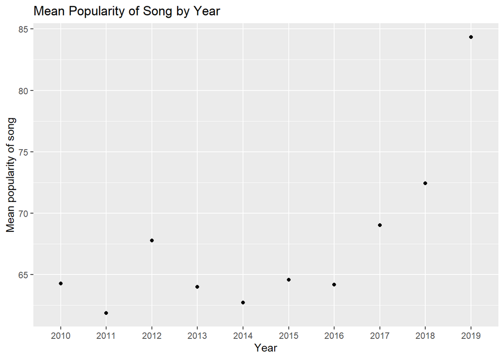

```r
# we can then graph it as necessary!

ggplot(data = spotify_popularity, mapping = aes( x = as.factor(year), y = mean_popularity)) +
  geom_point() +
  labs(x = "Year", y = "Mean popularity of song", title = "Mean Popularity of Song by Year")
```

You can also use summarize_if() to apply a conditional statement. The below dataframe answers the question: What are the average scores for each numeric category in the dataset by genre?

Note the fact that because *year* is numeric, R took the mean of the year. That doesn’t really make sense given the context of the data. So if we wanted to graph something with year, we would need to change our code so it grouped by year as well. Always think about your data in context!

```r
spotify_genres  <- spotify %>% # take spotify data
  group_by(genre) %>% # groups by genre of music
  summarize_if(is.numeric, mean) #summarizes all numeric variables by mean

head(spotify_genres)
```

```
## # A tibble: 6 x 6
##   genre             year   bpm    dB duration popularity
##   <chr>            <dbl> <dbl> <dbl>    <dbl>      <dbl>
## 1 acoustic pop     2012   155   -6       238        58.5
## 2 alaska indie     2013   132  -11       250        36
## 3 alternative r&b  2019   136   -9       198        84
## 4 art pop          2015.  115.  -8       261.       62.8
## 5 atl hip hop      2011.  103.  -4.8     284.       50
## 6 australian dance 2016.  129.  -4.5     243        62.3
```

### What if my data is not in the right format?

That happens sometimes! For that, we use *pivot_longer()* and *pivot_wider()*. These functions are covered in the bonus material!

# Miscellaneous Takeaways: Day 2

- When we make an R script, we try to organize our chunks of code. The first chunk is always the libraries you need to use in the script. The second chunk is always reading in the data. The third (and sometimes fourth, fifth, sixth) is data manipulation. After that I put all the code you need to make the models and the graphs.
- Remember to be careful with parentheses in ggplot2, and always map data using *aes()*.
- *dplyr* can take a little getting used to. Remember that Googling, StackOverflowing, and getting frustrated are just a part of the process. Reading the documentation help too There is a joke in the software development world regarding whether you should take 30 seconds to read the documentation or literally hours to debug.
- Below, we have a screenshot from the ggplot2 cheat sheet which can also be found in the R resources folder. It’s a great way to think about data!

[figure not shown]

```r
knitr::include_graphics("ggplot2.png")
```

### Stay tuned for our third day of content, where we’ll be putting it all together - readr, dplyr, and ggplot2. We’ll also be working in small groups :)